# R en RStudio installeren

Ludger Goeminne

Aangezien R en RStudio volledig gratis zijn, moedigen we alle studenten aan om hun eigen laptops te gebruiken, met R en RStudio vooraf geïnstalleerd. Een tweede optie is om gebruik te maken van RStudio via Athena, maar dit is dikwijls traag en de connectie is niet altijd even betrouwbaar. Een derde optie is gebruik maken van een “portable” versie van R en RStudio installeren op een USB-stick of op het bureaublad van de computer in de pc-klas.

De eerste optie, het installeren van R en RStudio verdient de voorkeur omdat het de meest eenvoudige is. Bovendien is de kans groot dat je RStudio nadien nog gaat nodig hebben voor data-analyses, bijvoorbeeld tijdens je thesis. De installaties van zowel R en RStudio zijn zeer eenvoudig. In dit document leggen we stap voor stap uit hoe je R en RStudio kan downloaden en installeren.

Wil je toch graag de portable versie van R en RStudio installeren op een computer in de pc-klas of op een USB-stick? Volg dan de instructies op: https://statomics.github.io/statistiekBasisCursus/assets/practica/practicum1/extra/portable_RStudio.html

## 1. R installeren

**Voor Windows-gebruikers**, ga naar https://cran.r-project.org/bin/windows/base/. Deze webpagina ziet er als volgt uit.

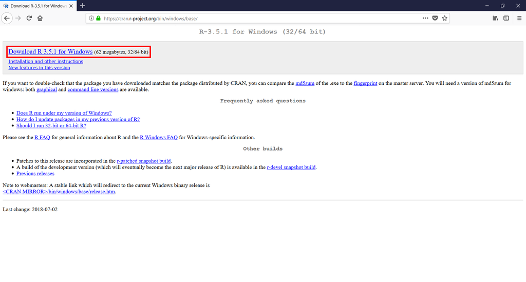

Klik op “Download R [versienummer] for Windows”.

**Mac-gebruikers**, ga naar: https://cran.r-project.org/bin/macosx/

Deze pagina ziet er als volgt uit.

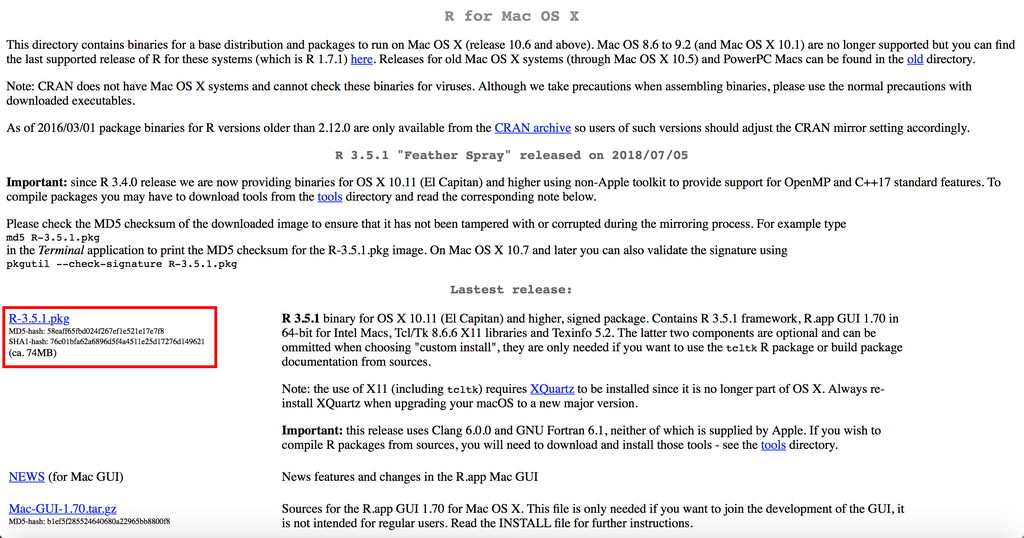

Klik op “R-[versienummer].pkg”.

Sla het bestand op en installeer het.

**Windows-gebruikers:** tijdens de installatie kan je eventueel opteren om de 64-bit files of 32-bit files niet te installeren als je een 32-bit of een 64-bit computer hebt, maar dit is volledig optioneel.

[figure not shown]

## 2. RStudio installeren

Ga naar https://www.rstudio.com/products/rstudio/download/. Deze pagina ziet er als volgt uit.

Klik op “Download” onder “FREE”.

[figure not shown]

Je gaat dan naar een overzichtsscherm waar je je besturingssysteem kunt kiezen. Download en installeer het overeenkomstige bestand.

[figure not shown]

Na installatie kan je RStudio openen. Dit scherm zou er ongeveer als volgt moeten uitzien.

[figure not shown]